# Variable Selection Exercise

2019-10-07

# Overview

This document will guide you through some data analysis tasks with a focus on fitting tree-based models and training them. We’ll also (re)-visit some other topics.

While this is in some sense a stand-alone analysis, I assume that you have worked through the *Data Analysis* exercise and are familiar with the dataset and all the things we discovered during the cleaning process. We’ll use the same dataset here but focus on a different outcome. Other than that, the way to work through the exercise is like in the *Data Analysis* exercise, namely by writing/completing the missing code.

# Project setup

We need a variety of different packages, which are loaded here. Install as needed. For this analysis, we’ll again use the `caret` package. If you use others, load them here.

```r
library('tidyr')
library('dplyr')
```

```r
library('forcats')
library('ggplot2')
library('knitr')
library('caret')
library('rpart')
library('rpart.plot')
```

# Data loading and cleaning

We will again use the Norovirus dataset.

```r
#Write code that loads the dataset
#You can of course re-use code you wrote in the other file.
d <- read.csv('norodata.csv',header=TRUE,stringsAsFactors=TRUE)
```

# Looking at the outcome

For this analysis, we consider as our main outcome of interest the season. This is a categorical outcome with more than 2 categories. Therefore, a logistic model won’t work. Fortunately, tree-based models can deal with multiple categories.

```r
#write code to take a look at the outcome variable (season)
table(d$season)
```

```
##
##          Fall Spring Summer Winter
##     67    164    222    126    443
```

We already knew from previous explorations that some entries do not have a season. We could either code them as “other” and keep them in the model, or remove them. Since it’s hard to see any potential scientific reason why there should be a correlation between an “other” season and some other model variable, we’ll remove it here.

We also notice that while winter is dominant (makes sense, we know that norovirus is more common in winter), we got a decent number of outbreaks for each season, so we shouldn’t have a problem with (un)balanced data.

```r
#write code that removes all observations that have an empty/missing value for season
#then drop the empty level and check that you have 4 categories for season left
d <- d %>% dplyr::filter( season !="") %>% droplevels()
table(d$season)
```

```
##
##   Fall Spring Summer Winter
##    164    222    126    443
```

# Selecting predictors

We will pick similar variables as previously, but with some changes. Keep the following variables: `Action1, CasesAll, Country, Deaths, EndMonth, GG2C4, Hemisphere, Hospitalizations, MeanD1, MeanI1, MedianD1, MedianI1, OBYear, Path1, RateAll, RiskAll, Season, Setting, StartMonth, State, Trans1, Vomit.`

```r
d <- d %>% dplyr::select(Action1, CasesAll, Country, Deaths, EndMonth, gg2c4, Hemisphere, Hospitalizations,  MeanD1, MeanI1, MedianD1, MedianI1, OBYear, Path1, RateAll, RiskAll, season, Setting_1, StartMonth, State, Trans1, Vomit)
dim(d)
```

```
## [1] 955  22
```

# Cleaning predictors

We’ll likely have to perform similar cleaning steps as before. A difference is that earlier we had to drop about half of the observations because no outcome was available. Here, we have outcome for every outbreak. Thus, there is more data to clean, which - as we will see - introduces a few issues we didn’t have before, since we dropped the troublesome observations early in the process.

Let’s first check for missing values.

```r
# write code that looks at missing values
print(colSums(is.na(d)))
```

```
##          Action1         CasesAll          Country           Deaths
##                0                5                0               42
##         EndMonth            gg2c4       Hemisphere Hospitalizations
##                0                0                0               42
##           MeanD1           MeanI1         MedianD1         MedianI1
##                0                0                0                0
##           OBYear            Path1          RateAll          RiskAll
##                0                0              104              116
##           season        Setting_1       StartMonth            State
##                0                0                0                0
##           Trans1            Vomit
##                0                1
```

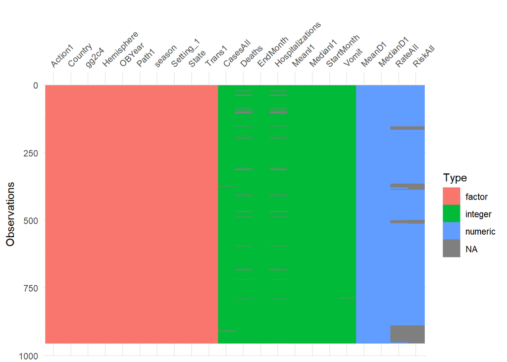

```r
visdat::vis_dat(d)
```

Looks like none of the new variables we included had a lot of missing, so we would be ok just removing any observation that has missing data. **However**, tree-based models can deal with missing data in predictors. Therefore, we’ll keep them for now. We’ll later compare how the model does or does not change if we remove those observations.

```r
#write code that cleans OBYear, convert it to numeric. Remove observations with OBYear = 0.
#also convert any other variables as needed
d <- d %>%  dplyr::mutate(Vomit = as.factor(Vomit)) %>%
            dplyr::filter(OBYear != "2002-2007") %>%
            dplyr::mutate(OBYear = as.numeric(as.character(OBYear))) %>%
            dplyr::filter(OBYear != 0)
```

Look at the data to see what else we need to do.

```r
str(d)
```

```
## 'data.frame':    953 obs. of  22 variables:
##  $ Action1         : Factor w/ 4 levels "No","Unknown",..: 3 3 3 3 3 3 3 3 3 4 ...
##  $ CasesAll        : int  15 65 27 4 15 6 40 10 116 45 ...
##  $ Country         : Factor w/ 21 levels "Australia","Brazil",..: 11 21 16 16 16 16 16 16 16 21 ...
##  $ Deaths          : int  0 0 0 0 0 0 0 0 0 0 ...
##  $ EndMonth        : int  12 9 0 0 0 0 0 0 11 11 ...
##  $ gg2c4           : Factor w/ 2 levels "","Yes": 2 1 2 1 2 1 1 1 2 1 ...
##  $ Hemisphere      : Factor w/ 2 levels "Northern","Southern": 1 1 1 1 1 1 1 1 1 1 ...
##  $ Hospitalizations: int  0 0 0 0 0 0 0 0 5 10 ...
##  $ MeanD1          : num  0 0 0 0 0 0 0 0 0 0 ...
##  $ MeanI1          : int  0 0 0 0 0 0 0 0 0 0 ...
##  $ MedianD1        : num  0 36 0 0 0 0 0 0 0 48 ...
##  $ MedianI1        : int  0 37 0 0 0 0 0 0 0 31 ...
##  $ OBYear          : num  1999 1998 2006 2006 2006 ...
##  $ Path1           : Factor w/ 4 levels "No","Unknown",..: 1 1 3 3 3 3 3 3 1 3 ...
##  $ RateAll         : num  0 39.8 20.8 100 60 ...
##  $ RiskAll         : num  0 108 130 4 25 ...
##  $ season          : Factor w/ 4 levels "Fall","Spring",..: 1 1 1 1 1 1 1 1 1 1 ...
##  $ Setting_1       : Factor w/ 374 levels "\tPsychiatric Care Center adjoined",..: 118 32 39 301 39 341 39 301 196 3 ...
##  $ StartMonth      : int  11 9 9 10 11 11 11 11 11 11 ...
##  $ State           : Factor w/ 36 levels "0","1","14 states: CA, UT, KS, WI, IL, IN, OH, GA, FL, NC, VA, WV, NY, PA,",..: 1 21 1 1 1 1 1 1 1 9 ...
##  $ Trans1          : Factor w/ 6 levels "Environmental",..: 5 2 2 2 2 2 2 2 5 2 ...
##  $ Vomit           : Factor w/ 2 levels "0","1": 2 2 2 2 2 2 2 2 2 2 ...
```

```r
summary(d)
```

```
##         Action1       CasesAll          Country        Deaths
##  No         :  1   Min.   :    1   Other    :397   Min.   :0.00000
##  Unknown    :  1   1st Qu.:    9   Japan    :371   1st Qu.:0.00000
##  Unspecified:742   Median :   25   USA      :106   Median :0.00000
##  Yes        :209   Mean   :  129   Australia: 21   Mean   :0.05379
##                    3rd Qu.:   64   Multiple : 17   3rd Qu.:0.00000
##                    Max.   :32150   Denmark  : 11   Max.   :9.00000
##                    NA's   :5       (Other)  : 30   NA's   :42
##     EndMonth      gg2c4        Hemisphere  Hospitalizations
##  Min.   : 0.000      :676   Northern:872   Min.   :  0.0000
##  1st Qu.: 0.000   Yes:277   Southern: 81   1st Qu.:  0.0000
##  Median : 0.000                            Median :  0.0000
##  Mean   : 2.559                            Mean   :  0.7113
##  3rd Qu.: 4.000                            3rd Qu.:  0.0000
##  Max.   :12.000                            Max.   :125.0000
##                                            NA's   :42
##      MeanD1            MeanI1           MedianD1          MedianI1
##  Min.   :  0.000   Min.   : 0.0000   Min.   :  0.000   Min.   : 0.000
##  1st Qu.:  0.000   1st Qu.: 0.0000   1st Qu.:  0.000   1st Qu.: 0.000
##  Median :  0.000   Median : 0.0000   Median :  0.000   Median : 0.000
##  Mean   :  1.558   Mean   : 0.7125   Mean   :  2.611   Mean   : 1.703
##  3rd Qu.:  0.000   3rd Qu.: 0.0000   3rd Qu.:  0.000   3rd Qu.: 0.000
##  Max.   :273.600   Max.   :48.0000   Max.   :235.200   Max.   :65.000
##
##      OBYear             Path1        RateAll          RiskAll
##  Min.   :1983   No         :197   Min.   :  0.00   Min.   :    0.0
##  1st Qu.:2000   Unknown    :  3   1st Qu.:  0.00   1st Qu.:    0.0
##  Median :2003   Unspecified:675   Median : 16.50   Median :   20.5
##  Mean   :2002   Yes        : 78   Mean   : 27.04   Mean   :  399.7
##  3rd Qu.:2005                     3rd Qu.: 49.00   3rd Qu.:  110.8
##  Max.   :2010                     Max.   :105.00   Max.   :35000.0
##                                   NA's   :103      NA's   :115
##     season                  Setting_1     StartMonth         State
##  Fall  :164   Restaurant         :104   Min.   : 0.000   0      :842
##  Spring:222   0                  : 85   1st Qu.: 2.000   NC     : 18
##  Summer:125   restaurant         : 70   Median : 5.000   NY     : 10
##  Winter:442   Hospital           : 39   Mean   : 5.894   AK     :  9
##               Hotel              : 25   3rd Qu.:10.000   FL     :  7
##               Nursing Care Center: 25   Max.   :12.000   MI     :  6
##               (Other)            :605                    (Other): 61
##               Trans1     Vomit
##  Environmental   : 11   0   :469
##  Foodborne       :373   1   :483
##  Person to Person:150   NA's:  1
##  Unknown         : 63
##  Unspecified     :284
##  Waterborne      : 72
##
```

Some things we noted previously. We need to remove the `Unspecified` entry in `Hemisphere` and recode `Action1` and `Path1` as described in the Data Analysis script, i.e. from `Unknown` to `Unspecified`. Also we want to group the `Setting_1` variable into just `Restaurant` and `Other` with . Again, remember that there are `restaurant` and `Restaurant` values, so you need to fix that too.

We’ll also recode the gg2c4 blank entries to “No”. We further note that `Action1` has a single `No` entry. Let’s remove that observation to prevent potential problems during cross-validation.

Let’s also lump country together, make 3 categories, Japan, USA, and Other.

As discussed previously, it makes sense to move the Waterborne to the Environmental in the `Trans1` variable. It also turns out that most outbreaks have no information for state, so best to drop the `State` variable.

Finally, move the outcome into the first column.

```r
# write code that performs the actions described above
# at the end, use the droplevels() command to remove empty factor levels
d <- d %>% dplyr::filter(Hemisphere != "Unspecified") %>%
            dplyr::mutate(Action1 = replace(Action1, Action1 == "Unknown", "Unspecified")) %>%
            dplyr::mutate(Path1 = replace(Path1, Path1 == "Unknown", "Unspecified")) %>%
            dplyr::mutate(Setting = fct_lump(Setting_1, n = 3)) %>%
            dplyr::mutate(Setting = fct_recode(Setting,
                                     "Restaurant" = "restaurant",
                                     "Other" = "0")) %>%
            dplyr::select(-Setting_1) %>%
            dplyr::filter(Action1 != "No") %>%
            dplyr::mutate(Trans1 = fct_recode(Trans1, "Environmental" = "Waterborne")) %>%
            mutate(gg2c4 = fct_recode(gg2c4, "No" = ""  )) %>%
            dplyr::mutate(Country = fct_lump(Country, n = 3)) %>%
            dplyr::select(-State) %>%
            dplyr::select(season, everything() ) %>%
            droplevels() #gets rid of unused/empty levels in factor variables
summary(d)
```

```
##     season           Action1       CasesAll        Country
##  Fall  :164   Unspecified:743   Min.   :    1.0   Japan:371
##  Spring:222   Yes        :209   1st Qu.:    9.0   USA  :106
##  Summer:125                     Median :   25.0   Other:475
##  Winter:441                     Mean   :  129.0
##                                 3rd Qu.:   63.5
##                                 Max.   :32150.0
##                                 NA's   :5
##      Deaths           EndMonth      gg2c4        Hemisphere
##  Min.   :0.00000   Min.   : 0.000   No :676   Northern:872
##  1st Qu.:0.00000   1st Qu.: 0.000   Yes:276   Southern: 80
##  Median :0.00000   Median : 0.000
##  Mean   :0.05385   Mean   : 2.555
##  3rd Qu.:0.00000   3rd Qu.: 4.000
##  Max.   :9.00000   Max.   :12.000
##  NA's   :42
##  Hospitalizations       MeanD1           MeanI1           MedianD1
##  Min.   :  0.0000   Min.   :  0.00   Min.   : 0.0000   Min.   :  0.000
##  1st Qu.:  0.0000   1st Qu.:  0.00   1st Qu.: 0.0000   1st Qu.:  0.000
##  Median :  0.0000   Median :  0.00   Median : 0.0000   Median :  0.000
##  Mean   :  0.7121   Mean   :  1.56   Mean   : 0.7132   Mean   :  2.614
##  3rd Qu.:  0.0000   3rd Qu.:  0.00   3rd Qu.: 0.0000   3rd Qu.:  0.000
##  Max.   :125.0000   Max.   :273.60   Max.   :48.0000   Max.   :235.200
##  NA's   :42
##     MedianI1          OBYear             Path1        RateAll
##  Min.   : 0.000   Min.   :1983   No         :197   Min.   :  0.00
##  1st Qu.: 0.000   1st Qu.:2000   Unspecified:677   1st Qu.:  0.00
##  Median : 0.000   Median :2003   Yes        : 78   Median : 16.50
##  Mean   : 1.705   Mean   :2002                     Mean   : 27.04
##  3rd Qu.: 0.000   3rd Qu.:2005                     3rd Qu.: 49.00
##  Max.   :65.000   Max.   :2010                     Max.   :105.00
##                                                    NA's   :102
##     RiskAll          StartMonth                  Trans1     Vomit
##  Min.   :    0.0   Min.   : 0.000   Environmental   : 83   0   :469
##  1st Qu.:    0.0   1st Qu.: 2.000   Foodborne       :373   1   :482
##  Median :   20.5   Median : 5.000   Person to Person:150   NA's:  1
##  Mean   :  399.7   Mean   : 5.894   Unknown         : 63
##  3rd Qu.:  110.8   3rd Qu.:10.000   Unspecified     :283
##  Max.   :35000.0   Max.   :12.000
##  NA's   :114
##        Setting
##  Other     :778
##  Restaurant:174
##
##
##
##
##
```

# Data visualization

We know our data fairly well by now, so we might not discover much new in any plots, but it’s always good to do them anyway. Let’s create a few plots showing the outcome and the predictors. We’ll start with the continuous predictors. I suggest scatter/box/violinplots with the outcome on the x-axis.

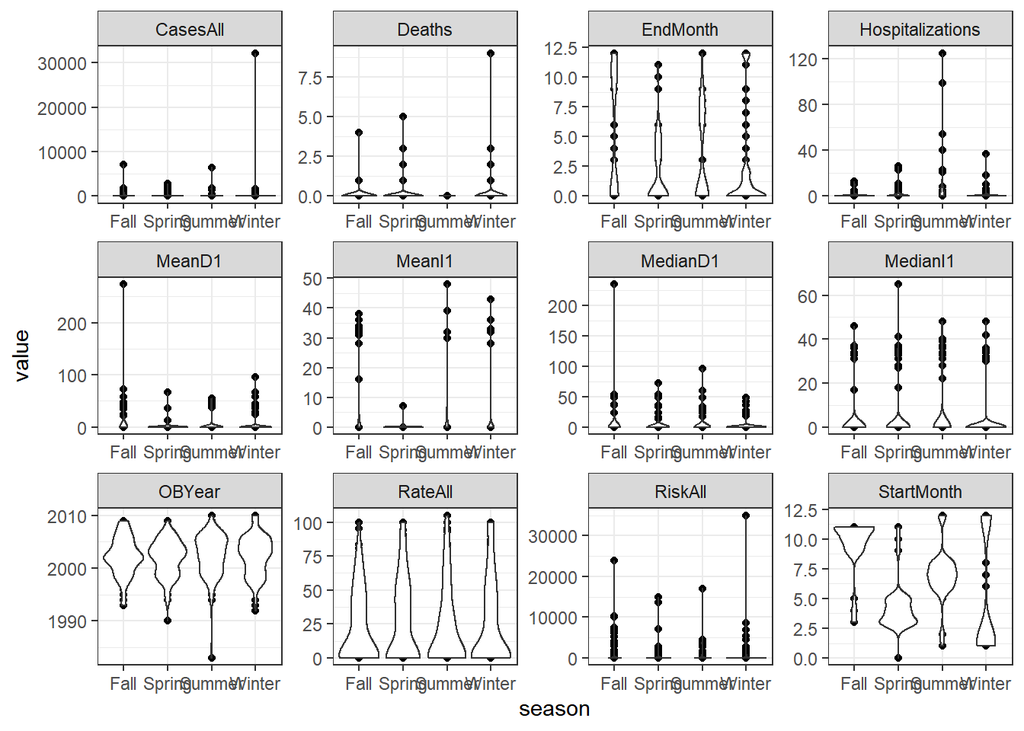

```r
#write code that produces plots showing our outcome of interest on the x-axis and each numeric predictor on the y-axis.
#you can use the facet_wrap functionality in ggplot for it, or do it some other way.
p1 <- d %>% select_if(is.numeric) %>% mutate(season = d$season) %>%
            gather(-season, key = "var", value = "value") %>%
            ggplot(aes(x = season, y=value)) + geom_point()  + geom_violin() +
            facet_wrap(~ var, scales = "free") + theme_bw()
plot(p1)
```

Things look ok, apart from the skew in the predictors we discussed previously.

Next, let’s create plots for the categorical variabless. You can use for instance `geom_count` for it, or some other representation. If you prefer lots of tables, that’s ok too.

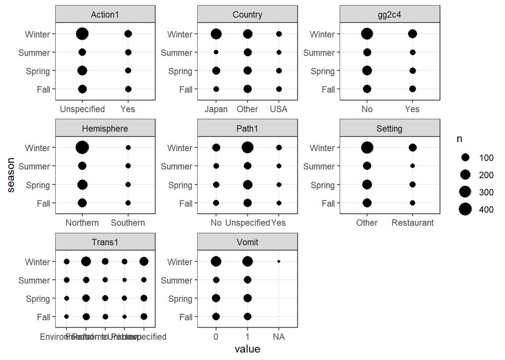

```r
#write code that produces plots or tables showing our outcome of interest and each categorical predictor.
p1 <- d %>% select_if(is.factor) %>%
            gather(-season, key = "var", value = "value") %>%
            ggplot(aes(x = value, y=season)) + geom_count()  +
            facet_wrap(~ var, scales = "free") + theme_bw()
print(p1)
```

Looks ok. Notice the NA for vomiting. We are ok with that for now.

```r
dim(d)
```

```
## [1] 952  21
```

```r
str(d)
```

```
## 'data.frame':    952 obs. of  21 variables:
##  $ season          : Factor w/ 4 levels "Fall","Spring",..: 1 1 1 1 1 1 1 1 1 1 ...
##  $ Action1         : Factor w/ 2 levels "Unspecified",..: 1 1 1 1 1 1 1 1 1 2 ...
##  $ CasesAll        : int  15 65 27 4 15 6 40 10 116 45 ...
##  $ Country         : Factor w/ 3 levels "Japan","USA",..: 1 2 3 3 3 3 3 3 3 2 ...
##  $ Deaths          : int  0 0 0 0 0 0 0 0 0 0 ...
##  $ EndMonth        : int  12 9 0 0 0 0 0 0 11 11 ...
##  $ gg2c4           : Factor w/ 2 levels "No","Yes": 2 1 2 1 2 1 1 1 2 1 ...
##  $ Hemisphere      : Factor w/ 2 levels "Northern","Southern": 1 1 1 1 1 1 1 1 1 1 ...
##  $ Hospitalizations: int  0 0 0 0 0 0 0 0 5 10 ...
##  $ MeanD1          : num  0 0 0 0 0 0 0 0 0 0 ...
##  $ MeanI1          : int  0 0 0 0 0 0 0 0 0 0 ...
##  $ MedianD1        : num  0 36 0 0 0 0 0 0 0 48 ...
##  $ MedianI1        : int  0 37 0 0 0 0 0 0 0 31 ...
##  $ OBYear          : num  1999 1998 2006 2006 2006 ...
##  $ Path1           : Factor w/ 3 levels "No","Unspecified",..: 1 1 2 2 2 2 2 2 1 2 ...
##  $ RateAll         : num  0 39.8 20.8 100 60 ...
##  $ RiskAll         : num  0 108 130 4 25 ...
##  $ StartMonth      : int  11 9 9 10 11 11 11 11 11 11 ...
##  $ Trans1          : Factor w/ 5 levels "Environmental",..: 5 2 2 2 2 2 2 2 5 2 ...
##  $ Vomit           : Factor w/ 2 levels "0","1": 2 2 2 2 2 2 2 2 2 2 ...
##  $ Setting         : Factor w/ 2 levels "Other","Restaurant": 1 1 1 2 1 1 1 2 1 1 ...
```

# Data splitting

Let’s do data splitting again. Use `caret` functions (or any other way you like) to split the data into 70/30 train/test portions.

```r
#d <- d %>% drop_na()
```

```r
set.seed(123)
trainset <- caret::createDataPartition(y = d$season, p = 0.7, list = FALSE)
data_train = d[trainset,] #extract observations/rows for training, assign to new variable
data_test = d[-trainset,] #do the same for the test set
```

# Model fitting

We’ll now explore fitting and training several tree-based models. We’ll also explore how including/excluding missing values and centering/scaling or not might affect the results.

## A null model

To define a null model, we need to determine what performance measure we want to track. Since we now have a categorical outcome with more than 2 categories, the regular 2x2 table/confusion matrix and measurements that rely on it don’t quite work. We can still define misclassification error. The null model still just predicts the most frequent category. We can use that as baseline performance.

```r
#write code that computes accuracy and misclassification error for a null model
outcome <- data_train$season
outcomename = "season"
most_common = names(which.max(table(outcome)))
null_pred <- factor(rep(most_common,length(outcome)), levels = levels(outcome))
MCE = sum(null_pred != outcome)/length(outcome)
print(MCE) #misclassification error
```

```
## [1] 0.5374251
```

```r
table(outcome)/length(outcome) #this shows what fraction is winter, which is the accuracy ( which is 1 - MCE).
```

```
## outcome
##      Fall    Spring    Summer    Winter
## 0.1721557 0.2335329 0.1317365 0.4625749
```

You should find that the null model has an accuracy of around 0.464 and thus a misclassification error of 0.536.

## Single predictor models

Now let’s consider single predictor models, i.e. we’ll fit the outcome to each predictor one at a time to get an idea of the importance of individual predictors. I’m actually not so sure if this makes a lot of sense, since a “tree” with only one predictor seems a bit silly. But I guess we can try, it’s similar to a 1-predictor GLM. We’ll also do some parameter tuning here. Looking at the [caret documentation](http://topepo.github.io/caret/available-models.html), we find that the tuning parameter for the `rpart` model is called cp. We could also find that using `modelLookup("rpart")`. We’ll set a simple vector of discrete values and let caret choose the specific values for cp.

```r
#There is probably a nicer tidyverse way of doing this. I just couldn't think of it, so did it this way.
set.seed(1111) #makes each code block reproducible
fitControl <- trainControl(method="repeatedcv",number=5,repeats=5) #setting CV method for caret
Npred <- ncol(data_train)-1 # number of predictors
resultmat <- data.frame(Variable = names(data_train)[-1], Accuracy = rep(0,Npred)) #store performance for each variable
for (n in 2:ncol(data_train)) #loop over each predictor. For this to work, outcome must be in 1st column
{
  fit1 <- train( as.formula(paste(outcomename, "~",names(data_train)[n])) , data = data_train, method = "rpart", trControl = fitControl, na.action = na.pass, tuneLength = 10)
resultmat[n-1,2]= max(fit1$results$Accuracy)
}
print(resultmat)
```

```
##            Variable  Accuracy
## 1           Action1 0.4625783
## 2          CasesAll 0.4371258
## 3           Country 0.4523908
## 4            Deaths 0.4625782
## 5          EndMonth 0.6078051
## 6             gg2c4 0.4625783
## 7        Hemisphere 0.4562893
## 8  Hospitalizations 0.4607826
## 9            MeanD1 0.4631575
## 10           MeanI1 0.4649637
## 11         MedianD1 0.4577710
## 12         MedianI1 0.4548254
## 13           OBYear 0.4787562
## 14            Path1 0.4625805
## 15          RateAll 0.4574609
## 16          RiskAll 0.4661742
## 17       StartMonth 0.8921997
## 18           Trans1 0.4556872
## 19            Vomit 0.4625847
## 20          Setting 0.4625804
```

So looks like most of the single predictor models don’t have accuracy much better than the null. 2 exceptions are `StartMonth` and `EndMonth`. Well, we would expect that the outbreak season and the month at which the outbreak started (and ended) have a strong correlation. I kept those variables here to see if that would happen and get some reassurance that our model works ok. Of course in a real analysis, keeping those seems kind of silly, we wouldn’t learn much from it (other than that data entry seemed to have been done ok).

# Full model

Anywa, now let’s fit a tree to the full model with all predictors.

```r
set.seed(1111) #makes each code block reproducible
fitControl <- trainControl(method="repeatedcv",number=5,repeats=5)
fit1 = train(season  ~ ., data=data_train, method="rpart",  trControl = fitControl, na.action = na.pass, tuneLength = 10)
print(fit1$results)
```

```
##            cp  Accuracy     Kappa AccuracySD    KappaSD
## 1  0.00000000 0.9733450 0.9608083 0.01419000 0.02099063
## 2  0.02135562 0.9727480 0.9598555 0.01463699 0.02178684
## 3  0.04271123 0.9248201 0.8900274 0.02820307 0.04147341
## 4  0.06406685 0.8921723 0.8424778 0.02326732 0.03397198
## 5  0.08542247 0.8921723 0.8424778 0.02326732 0.03397198
## 6  0.10677809 0.8921723 0.8424778 0.02326732 0.03397198
## 7  0.12813370 0.8921723 0.8424778 0.02326732 0.03397198
## 8  0.14948932 0.8921723 0.8424778 0.02326732 0.03397198
## 9  0.17084494 0.8921723 0.8424778 0.02326732 0.03397198
## 10 0.19220056 0.6630268 0.4042284 0.19975184 0.40034135
```

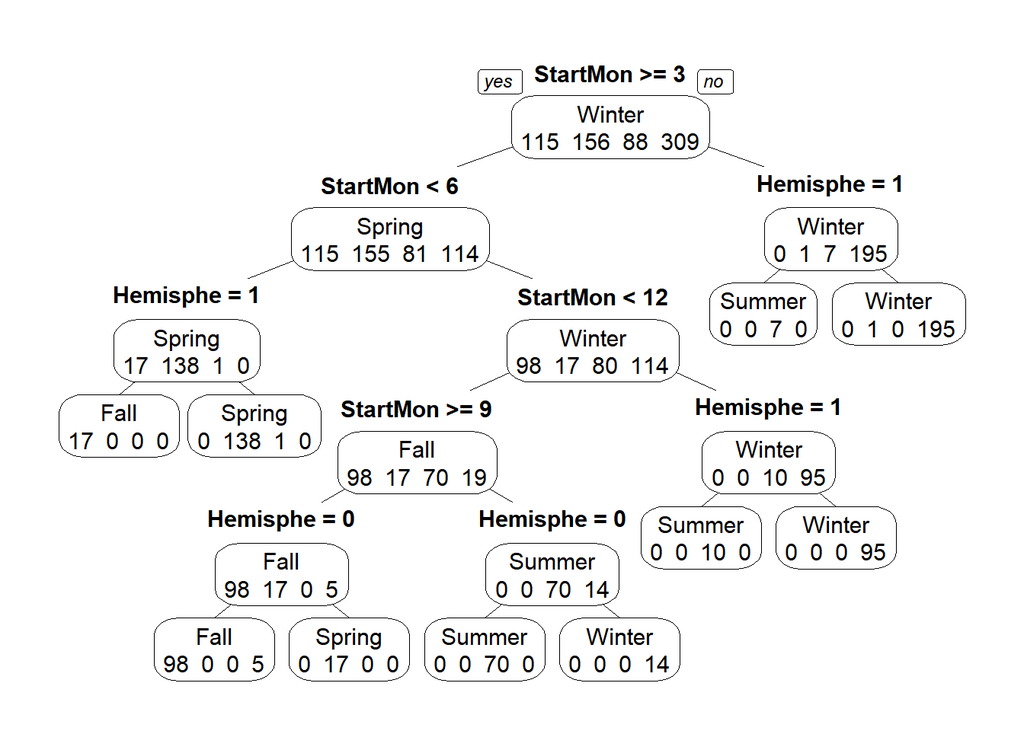

```r
prp(fit1$finalModel, extra = 1, type = 1)
```

```r
ww=17.8/2.54; wh=ww; #for saving plot
dev.print(device=png,width=ww,height=wh,units="in",res=600,file="rparttree.png") #save tree to file
```

So the model splits on month, repeatedly. And it also splits on hemisphere, which makes sense since the seasons are switched on the Southern hemisphere. This is also likely the reason why the model with month only didn’t produce a perfect fit. It could get one hemisphere right, but not both. With both bits of information, we can get almost perfect predictions.

Note 2 distinguising features of this tree model: Some (in fact almost all) predictor variables are not part of the model, and some predictor variables are used more than once.

You can also see on each leaf (end node) the final predictions for the category. Note that by default, levels are ordered alphabetically (Fall/Spring/Summer/Winter). We could re-order the factor manually in the more logical Spring/Summer/Fall/Winter order. I would do that for a ‘real’ analysis where I want to show a nice final result, but here we can leave it as is, as long as we pay attention to this fact.

# Re-fitting the tree

So the above produces an almost perfect fit, and thus more powerful models are not really needed. However, using start and end month seems a bit like cheating. Of course, if we give the model that kind of information, it will do well. Let’s make it harder and remove those 2 variables, from both the training and test sets.

```r
#write code that removes StartMonth and EndMonth from both training and test sets
data_train <- data_train %>% select( -StartMonth, -EndMonth)
data_test <- data_test %>% select( -StartMonth, -EndMonth)
```

Now, let’s re-do the fit above fitting a single tree.

```r
#copy and paste the code from above that fits the single tree. Also plot the tree.
set.seed(1111) #makes each code block reproducible
fitControl <- trainControl(method="repeatedcv",number=5,repeats=5)
fit1 = train(season  ~ ., data=data_train, method="rpart",  trControl = fitControl, na.action = na.pass, tuneLength = 10)
print(fit1$results)
```

```
##             cp  Accuracy      Kappa AccuracySD    KappaSD
## 1  0.000000000 0.4464522 0.16721942 0.03606651 0.04939987
## 2  0.001702259 0.4497403 0.17000499 0.03758484 0.05261205
## 3  0.003404519 0.4664995 0.18412808 0.03296383 0.04579931
## 4  0.005106778 0.4757714 0.18735515 0.02813824 0.04342045
## 5  0.006809037 0.4772797 0.18459751 0.02807813 0.04204943
## 6  0.008511297 0.4763797 0.16270214 0.02964603 0.05250587
## 7  0.010213556 0.4766668 0.15418855 0.02719376 0.04884373
## 8  0.011915816 0.4766736 0.12594323 0.02866616 0.05346269
## 9  0.013618075 0.4793691 0.10640938 0.02538840 0.06377901
## 10 0.015320334 0.4742787 0.08333233 0.02062652 0.05937612
```

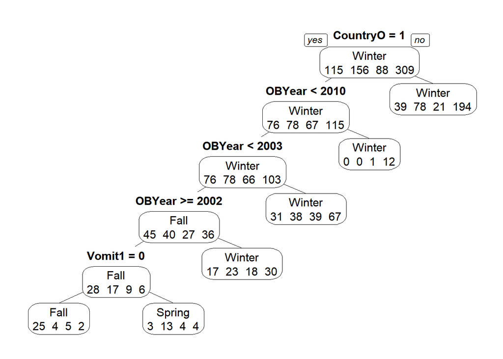

```r
prp(fit1$finalModel, extra = 1, type = 1)
```